# 2_cleaning_ds

### Data Cleaning

```python
#Import libraries
import pandas as pd
import numpy as np
import matplotlib.pyplot as plt
import seaborn as sns
```

```python
data = pd.read_csv("diabetic_data.csv")
```

### 1. Check duplicates

```python
#Multiple inpatient visits per patient
print(data.duplicated(subset=['encounter_id']).any())
print(data.duplicated(subset=['patient_nbr']).any())
```

```
False
True
```

The dataset contained multiple inpatient visits for some patients and the observations could not be considered as statistically independent as it violates one of the assumptions of logistic regression model. Hence, we considered only the first encounter for each patient as the primary admission and determined whether or not they were readmitted within 30 days.

```python
data = data.drop_duplicates(subset= ['patient_nbr'], keep = 'first')
data.shape
```

```
(71518, 50)
```

### 2. Change 'None' values

```python
na_columns = data.isna().sum()
print("Columns with NA values:")
print(na_columns[na_columns > 0])
```

```
Columns with NA values:
max_glu_serum    68062
A1Cresult        58532
dtype: int64
```

```python
# Replace 'None' values with 'No'
data = data.fillna('Not measured')
```

71,518 unique first inpatient visit is retained for further analysis.

Since these two features concern with the result of maximumm glucose level test and A1C test were taken and these tests may not be taken for some of the patient encounter, it is normal to contain none in these columns.  
Instead of removing these responses, we have filled the null values with a new class "not measured" to better reflecting the situation.

### 3. Drop columns

##### 3.1. single unique value

```python
single_value_columns = [col for col in data.columns if data[col].nunique() == 1]
single_value_columns
```

```
['examide', 'citoglipton', 'glimepiride-pioglitazone']
```

```python
data.drop(columns=single_value_columns, inplace=True)
```

In the introduction of the dataset, we have examined that there are a few features, 'examide', 'citoglipton', 'glimepiride-pioglitazone', only contain one class, "No".  
We consider these features not being significant for further analysis and decide the drop the column for data storage and efficiency purpose.

##### 3.2. Check '?' values

```python
nan_counts = (data == "?").sum()

total_rows = len(data)
nan_percentage = (nan_counts / total_rows) * 100

# Filter only columns with NaN values
nan_columns = nan_counts[nan_counts > 0].index
nan_summary = pd.DataFrame({
    # "Column Name": nan_columns,
    "? Count": nan_counts[nan_columns],
    "? Percentage %": nan_percentage[nan_columns].round(2)  # Round to 2 decimal places
})

# Display the result
nan_summary
```

|  | ? Count | ? Percentage % |
| --- | --- | --- |
| race | 1948 | 2.72 |
| weight | 68665 | 96.01 |
| payer_code | 31043 | 43.41 |
| medical_specialty | 34477 | 48.21 |
| diag_1 | 11 | 0.02 |
| diag_2 | 294 | 0.41 |
| diag_3 | 1225 | 1.71 |

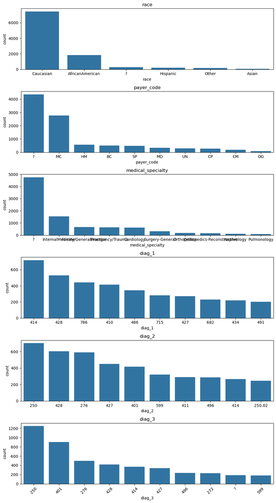

```python
def plot_selected_distributions(df, columns, sample_size=10000):
    selected_df = df[columns]  # Select only required columns

    # Sample if dataset is too large
    if len(df) > sample_size:
        selected_df = selected_df.sample(sample_size, random_state=42)

    num_cols = selected_df.select_dtypes(include=['number']).columns
    cat_cols = selected_df.select_dtypes(include=['object', 'category']).columns

    # Plot numerical columns (Horizontal histogram)
    if len(num_cols) > 0:
        fig, axes = plt.subplots(nrows=len(num_cols), ncols=1, figsize=(10, len(num_cols) * 3))
        if len(num_cols) == 1:
            axes = [axes]  # Ensure axes is iterable

        for i, col in enumerate(num_cols):
            sns.histplot(selected_df[col].dropna(), kde=True, ax=axes[i])
            axes[i].set_title(col)

        plt.tight_layout()
        plt.show()

    # Plot categorical columns (Vertical count plot)
    if len(cat_cols) > 0:
        fig, axes = plt.subplots(nrows=len(cat_cols), ncols=1, figsize=(10, len(cat_cols) * 3))
        if len(cat_cols) == 1:
            axes = [axes]  # Ensure axes is iterable

        for i, col in enumerate(cat_cols):
            sns.countplot(x=selected_df[col], order=selected_df[col].value_counts().index[:10], ax=axes[i])
            axes[i].set_title(col)

        plt.xticks(rotation=45)  # Rotate x-axis labels if needed
        plt.tight_layout()
        plt.show()


# Example: Specify 6 columns to analyze
selected_columns = ['race', 'payer_code', 'medical_specialty', 'diag_1', 'diag_2', 'diag_3']  # Replace with actual column names

# Call the function
plot_selected_distributions(data, selected_columns)
```

```python
columns_to_drop = ["weight"]
data.drop(columns=columns_to_drop, inplace=True)
```

Since the Weight featire was considered to be too sparse, ~96% and we decide to not include it in further analysis.

### 4. Fill ?

```python
columns_to_replace = ['payer_code', 'medical_specialty']
data[columns_to_replace] = data[columns_to_replace].replace('?', 'Missing')
```

For feature "payer_code" and "medical_specialty", we decide to create a new category "Missing" to cater the "?" values.  
The former feature represents the insurance coverage of the encounter and the latter represents the specialty of the admitting physician of the encounter.  
We consider it being normal for these information not being disclosed during data collection as they are not compulsory to be collected in relation to the research study.

```python
columns_to_fill = ["race", "diag_1", "diag_2", "diag_3"]
for col in columns_to_fill:
    mode_value = data[data[col] != "?"][col].mode()[0]  # Get the most frequent value excluding '?'
    data[col] = data[col].replace("?", mode_value)
```

### 5. Outliers check

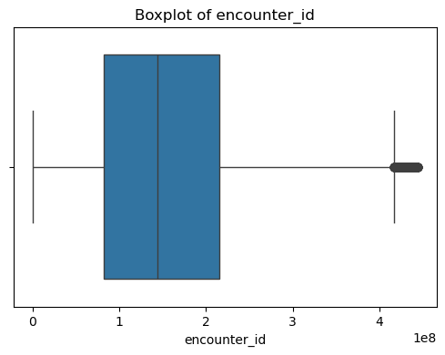

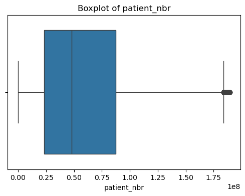

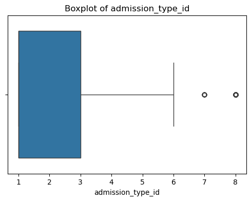

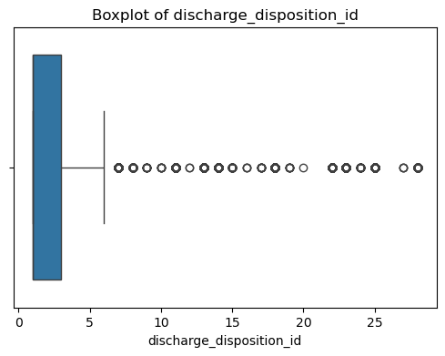

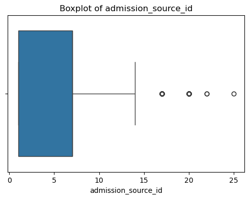

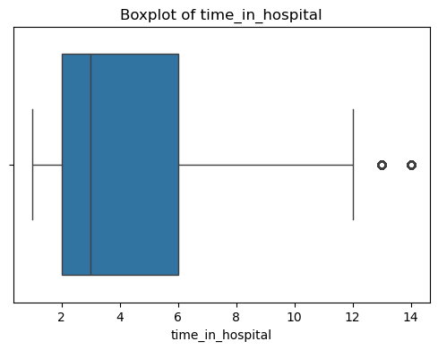

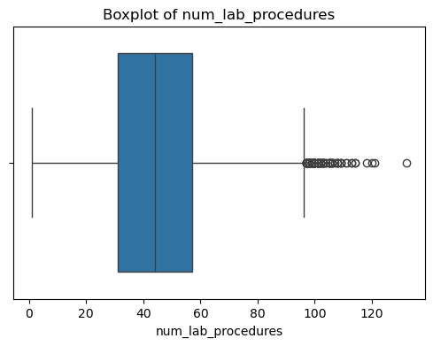

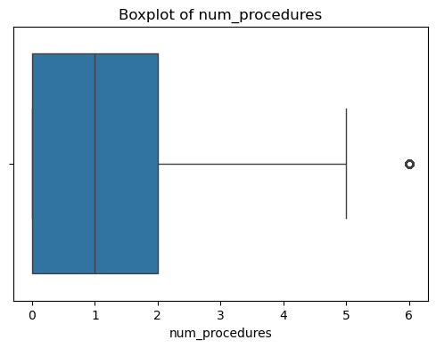

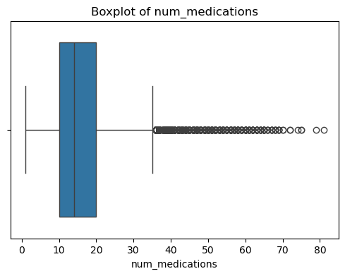

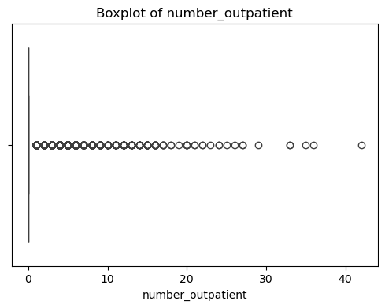

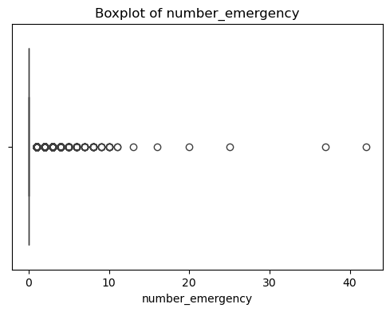

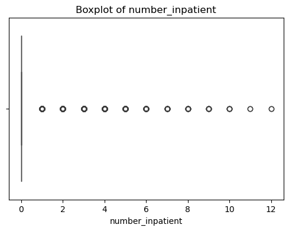

[34 more figures not shown]

```python
def plot_outliers(df, num_vars, cat_vars):
    # Boxplots for numerical variables
    for col in num_vars:
        plt.figure(figsize=(6, 4))
        sns.boxplot(x=df[col])
        plt.title(f'Boxplot of {col}')
        plt.show()

    # Bar plots for categorical variables
    for col in cat_vars:
        plt.figure(figsize=(6, 4))
        sns.countplot(x=df[col])
        plt.title(f'Bar Plot of {col}')
        plt.xticks(rotation=45)
        plt.show()

# Example usage
num_vars = data.select_dtypes(include=['number']).columns.tolist()
cat_vars = data.select_dtypes(include=['object', 'category']).columns.tolist()

plot_outliers(data, num_vars, cat_vars)
```

Why keep the outliers:  
Medical Insights: Outliers might represent rare but critical cases, such as extreme glucose levels, that could provide valuable insights into high-risk patients.

Real-World Representation: Excluding outliers may remove important variations in patient conditions, making your model less applicable to real-world scenarios.

Predictive Model Performance: If your goal is to predict extreme cases (e.g., diabetic emergencies), keeping outliers ensures the model learns from those critical instances.

Clinical Decision Support: Some outliers might indicate early warning signs of severe complications, which can be essential for medical diagnosis and treatment planning

### 6. Fixing diag columns

```python
def categorize_icd9(code):
    try:
        code = int(float(code))  # Convert to integer if possible
    except ValueError:
        return "Other"

    if 390 <= code <= 459 or code == 785:
        return "Circulatory"
    elif 460 <= code <= 519 or code == 786:
        return "Respiratory"
    elif 520 <= code <= 579 or code == 787:
        return "Digestive"
    elif str(code).startswith("250"):
        return "Diabetes"
    elif 800 <= code <= 999:
        return "Injury"
    elif 710 <= code <= 739:
        return "Musculoskeletal"
    elif 580 <= code <= 629 or code == 788:
        return "Genitourinary"
    elif 140 <= code <= 239:
        return "Neoplasms"
    elif 780 <= code <= 781 or 784 == code or 790 <= code <= 799:
        return "Neoplasms"
    elif 240 <= code <= 279:
        return "Neoplasms"
    elif 680 <= code <= 709 or code == 782:
        return "Other"
    elif 1 <= code <= 139 or 290 <= code <= 319 or 280 <= code <= 289 or 320 <= code <= 359:
        return "Other"
    elif 360 <= code <= 389 or 630 <= code <= 679 or 740 <= code <= 759:
        return "Other"
    else:
        return "Other"
```

```python
data[['diag_1', 'diag_2', 'diag_3']] = data[['diag_1', 'diag_2', 'diag_3']].map(categorize_icd9)
```

### 7. Check data type mismatch

```python
cat_cols = data.select_dtypes(include=['object', 'category']).columns

# Print rows where categorical columns contain numeric values
for col in cat_cols:
    print(f"Checking column: {col}")
    print(data[data[col].str.isnumeric()])
```

```
Checking column: race
Empty DataFrame
Columns: [encounter_id, patient_nbr, race, gender, age, admission_type_id, discharge_disposition_id, admission_source_id, time_in_hospital, payer_code, medical_specialty, num_lab_procedures, num_procedures, num_medications, number_outpatient, number_emergency, number_inpatient, diag_1, diag_2, diag_…
Index: []

[0 rows x 46 columns]
Checking column: gender
Empty DataFrame
Columns: [encounter_id, patient_nbr, race, gender, age, admission_type_id, discharge_disposition_id, admission_source_id, time_in_hospital, payer_code, medical_specialty, num_lab_procedures, num_procedures, num_medications, number_outpatient, number_emergency, number_inpatient, diag_1, diag_2, diag_…
Index: []

[0 rows x 46 columns]
Checking column: age
Empty DataFrame
Columns: [encounter_id, patient_nbr, race, gender, age, admission_type_id, discharge_disposition_id, admission_source_id, time_in_hospital, payer_code, medical_specialty, num_lab_procedures, num_procedures, num_medications, number_outpatient, number_emergency, number_inpatient, diag_1, diag_2, diag_…
Index: []

[0 rows x 46 columns]
Checking column: payer_code
Empty DataFrame
Columns: [encounter_id, patient_nbr, race, gender, age, admission_type_id, discharge_disposition_id, admission_source_id, time_in_hospital, payer_code, medical_specialty, num_lab_procedures, num_procedures, num_medications, number_outpatient, number_emergency, number_inpatient, diag_1, diag_2, diag_…
Index: []

[0 rows x 46 columns]
Checking column: medical_specialty
Empty DataFrame
Columns: [encounter_id, patient_nbr, race, gender, age, admission_type_id, discharge_disposition_id, admission_source_id, time_in_hospital, payer_code, medical_specialty, num_lab_procedures, num_procedures, num_medications, number_outpatient, number_emergency, number_inpatient, diag_1, diag_2, diag_…
Index: []

[0 rows x 46 columns]
Checking column: diag_1
Empty DataFrame
Columns: [encounter_id, patient_nbr, race, gender, age, admission_type_id, discharge_disposition_id, admission_source_id, time_in_hospital, payer_code, medical_specialty, num_lab_procedures, num_procedures, num_medications, number_outpatient, number_emergency, number_inpatient, diag_1, diag_2, diag_…
Index: []

[0 rows x 46 columns]
Checking column: diag_2
Empty DataFrame
Columns: [encounter_id, patient_nbr, race, gender, age, admission_type_id, discharge_disposition_id, admission_source_id, time_in_hospital, payer_code, medical_specialty, num_lab_procedures, num_procedures, num_medications, number_outpatient, number_emergency, number_inpatient, diag_1, diag_2, diag_…
Index: []
```

[output cut: 143 more lines]

```
Index: []

[0 rows x 46 columns]
Checking column: diabetesMed
Empty DataFrame
Columns: [encounter_id, patient_nbr, race, gender, age, admission_type_id, discharge_disposition_id, admission_source_id, time_in_hospital, payer_code, medical_specialty, num_lab_procedures, num_procedures, num_medications, number_outpatient, number_emergency, number_inpatient, diag_1, diag_2, diag_…
Index: []

[0 rows x 46 columns]
Checking column: readmitted
Empty DataFrame
Columns: [encounter_id, patient_nbr, race, gender, age, admission_type_id, discharge_disposition_id, admission_source_id, time_in_hospital, payer_code, medical_specialty, num_lab_procedures, num_procedures, num_medications, number_outpatient, number_emergency, number_inpatient, diag_1, diag_2, diag_…
Index: []

[0 rows x 46 columns]
```

No categorical columns with numeric data

```python
num_cols = data.select_dtypes(include=['int64', 'float64']).columns

# Print rows where numerical columns contain non-numeric values
for col in num_cols:
    print(f"Checking column: {col}")
    print(data[~data[col].apply(lambda x: isinstance(x, (int, float)))])
```

```
Checking column: encounter_id
Empty DataFrame
Columns: [encounter_id, patient_nbr, race, gender, age, admission_type_id, discharge_disposition_id, admission_source_id, time_in_hospital, payer_code, medical_specialty, num_lab_procedures, num_procedures, num_medications, number_outpatient, number_emergency, number_inpatient, diag_1, diag_2, diag_…
Index: []

[0 rows x 46 columns]
Checking column: patient_nbr
Empty DataFrame
Columns: [encounter_id, patient_nbr, race, gender, age, admission_type_id, discharge_disposition_id, admission_source_id, time_in_hospital, payer_code, medical_specialty, num_lab_procedures, num_procedures, num_medications, number_outpatient, number_emergency, number_inpatient, diag_1, diag_2, diag_…
Index: []

[0 rows x 46 columns]
Checking column: admission_type_id
Empty DataFrame
Columns: [encounter_id, patient_nbr, race, gender, age, admission_type_id, discharge_disposition_id, admission_source_id, time_in_hospital, payer_code, medical_specialty, num_lab_procedures, num_procedures, num_medications, number_outpatient, number_emergency, number_inpatient, diag_1, diag_2, diag_…
Index: []

[0 rows x 46 columns]
Checking column: discharge_disposition_id
Empty DataFrame
Columns: [encounter_id, patient_nbr, race, gender, age, admission_type_id, discharge_disposition_id, admission_source_id, time_in_hospital, payer_code, medical_specialty, num_lab_procedures, num_procedures, num_medications, number_outpatient, number_emergency, number_inpatient, diag_1, diag_2, diag_…
Index: []

[0 rows x 46 columns]
Checking column: admission_source_id
Empty DataFrame
Columns: [encounter_id, patient_nbr, race, gender, age, admission_type_id, discharge_disposition_id, admission_source_id, time_in_hospital, payer_code, medical_specialty, num_lab_procedures, num_procedures, num_medications, number_outpatient, number_emergency, number_inpatient, diag_1, diag_2, diag_…
Index: []

[0 rows x 46 columns]
Checking column: time_in_hospital
Empty DataFrame
Columns: [encounter_id, patient_nbr, race, gender, age, admission_type_id, discharge_disposition_id, admission_source_id, time_in_hospital, payer_code, medical_specialty, num_lab_procedures, num_procedures, num_medications, number_outpatient, number_emergency, number_inpatient, diag_1, diag_2, diag_…
Index: []

[0 rows x 46 columns]
Checking column: num_lab_procedures
Empty DataFrame
Columns: [encounter_id, patient_nbr, race, gender, age, admission_type_id, discharge_disposition_id, admission_source_id, time_in_hospital, payer_code, medical_specialty, num_lab_procedures, num_procedures, num_medications, number_outpatient, number_emergency, number_inpatient, diag_1, diag_2, diag_…
Index: []
```

[output cut: 23 more lines]

```
Index: []

[0 rows x 46 columns]
Checking column: number_inpatient
Empty DataFrame
Columns: [encounter_id, patient_nbr, race, gender, age, admission_type_id, discharge_disposition_id, admission_source_id, time_in_hospital, payer_code, medical_specialty, num_lab_procedures, num_procedures, num_medications, number_outpatient, number_emergency, number_inpatient, diag_1, diag_2, diag_…
Index: []

[0 rows x 46 columns]
Checking column: number_diagnoses
Empty DataFrame
Columns: [encounter_id, patient_nbr, race, gender, age, admission_type_id, discharge_disposition_id, admission_source_id, time_in_hospital, payer_code, medical_specialty, num_lab_procedures, num_procedures, num_medications, number_outpatient, number_emergency, number_inpatient, diag_1, diag_2, diag_…
Index: []

[0 rows x 46 columns]
```

No numeric columns with categorical data

```python
data.to_csv("../data/cleaned_dataset.csv")
```